# Lab 8

## Part 1

## Ido Israeli (ID - 212432439) Jonathan Derhy (ID - 315856377)

```python
import numpy as np
import pandas as pd
import math
import warnings
warnings.filterwarnings('ignore')
import matplotlib.pyplot as plt
from sklearn.metrics import roc_curve, auc
```

### Functions

```python
#
def functionValue(x):
    return (x + 2)*(x + 1)*(x - 4)*(x - 7)

#
def functionValues(X):
    f = []
    for x in X:
        f.append(functionValue(x))
    return f

#
def functionDerivativeValue(x):
    return (4*x**3)+(-24*x**2)+(-6*x)+62

#
def functionDerivativeValues(X):
    f_tag = []
    for x in X:
        f_tag.append(functionDerivativeValue(x))
    return f_tag
```

```python
#
def gradientStep(alpha, x):
    return (x - alpha*functionDerivativeValue(x))

#
def gradientTsteps(T, alpha, x0):
    steps = [x0]
    for t in range(T):
        steps.append(gradientStep(alpha, steps[t]))
    return steps
```

```python
#
def draw_f_xt_forXt(Xt, title):
    X = np.linspace(-4, 9, 1000)
    f = functionValues(X)
    plt.plot(X, f, 'green', label="f(x)")

    f_xt = functionValues(Xt)
    plt.plot(Xt, f_xt, color='blue', marker='o', label=r'$f(x_t)$')

    plt.xlabel('x')
    plt.ylabel('f(x)')
    plt.title(title)
    plt.legend(loc="upper left")
    return

#
def drawXt_and_f_xt(T, alpha, x0):
    Xt = gradientTsteps(T, alpha, x0)
    draw_f_xt_forXt(Xt, fr'f(x) and $f(x_t)$ when T={T}, $\alpha={alpha}$ and $x_0 = {x0}$')
    return

#
def draw_f_tag_xt_forXt(Xt, title):
    X = np.linspace(-4, 9, 1000)
    f_tag = functionDerivativeValues(X)
    plt.plot(X, f_tag, 'red', label="f'(x)")

    f_tag_xt = functionDerivativeValues(Xt)
    plt.plot(Xt, f_tag_xt, color='orange', marker='o', label=r"$f'(x_t)$")

    plt.xlabel('x')
    plt.ylabel("f'(x)")
    plt.title(title)
    plt.legend(loc="upper left")
    return

#
def drawXt_and_f_tag_xt(T, alpha, x0):
    Xt = gradientTsteps(T, alpha, x0)
    draw_f_tag_xt_forXt(Xt, fr"f'(x) and $f'(x_t)$ when T={T}, $\alpha={alpha}$ and $x_0 = {x0}$")
    return

#
def drawFunctionsBasedOnDataFrame(df, T):
    for idx in range(df.shape[0]):
        f = plt.figure()
        f.set_figwidth(14)
        f.set_figheight(10)
        plt.subplot(2, 1, 1)
        drawXt_and_f_xt(T, df["alpha"].iloc[idx], df["x_0"].iloc[idx])
        plt.subplot(2, 1, 2)
        drawXt_and_f_tag_xt(T, df["alpha"].iloc[idx], df["x_0"].iloc[idx])
    return
```

### Setting the Parameters

```python
T = [20, 3 ,200]
params = {'x_0': [4, 4, 8, 8, -3, -3],
         'alpha': [0.02, 0.002, 0.02, 0.002, 0.02, 0.001]}
parameters = pd.DataFrame(data=params)
parameters.index += 1
print(f'The Number of Updates: {T}\n\nThe Parameters:\n{parameters}')
```

```
The Number of Updates: [20, 3, 200]

The Parameters:
   x_0  alpha
1    4  0.020
2    4  0.002
3    8  0.020
4    8  0.002
5   -3  0.020
6   -3  0.001
```

### When $T = 20$

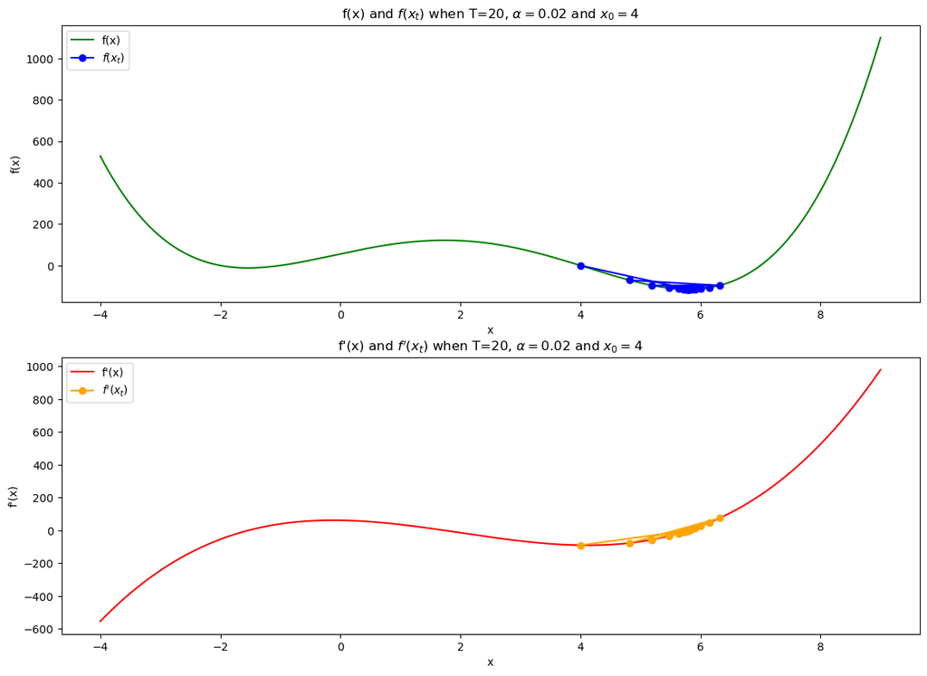

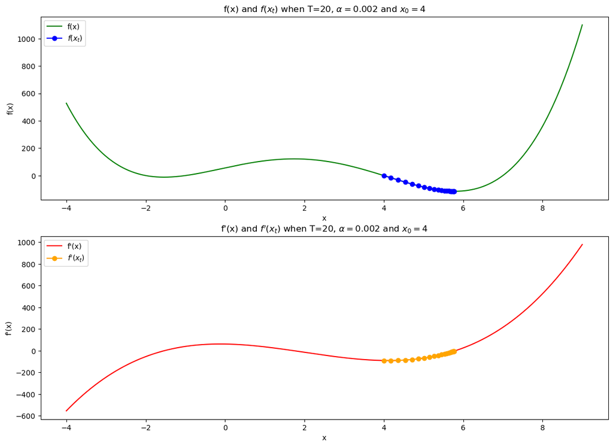

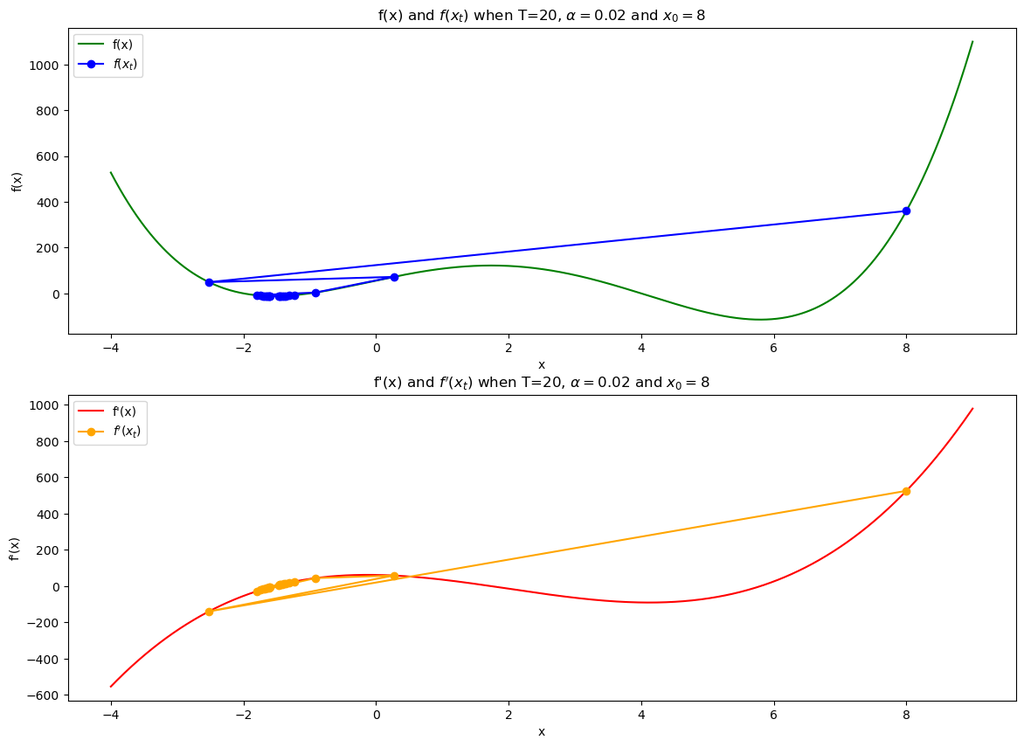

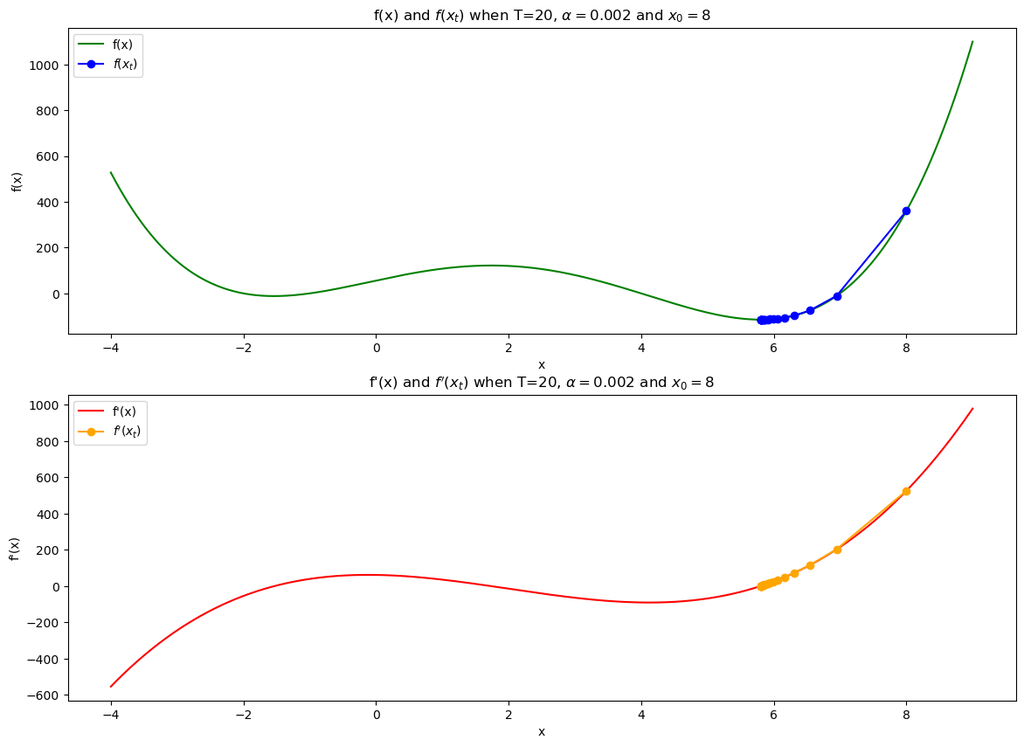

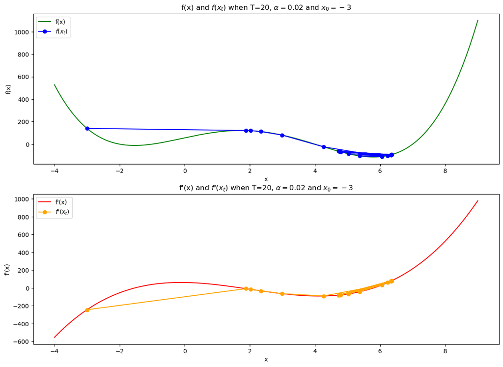

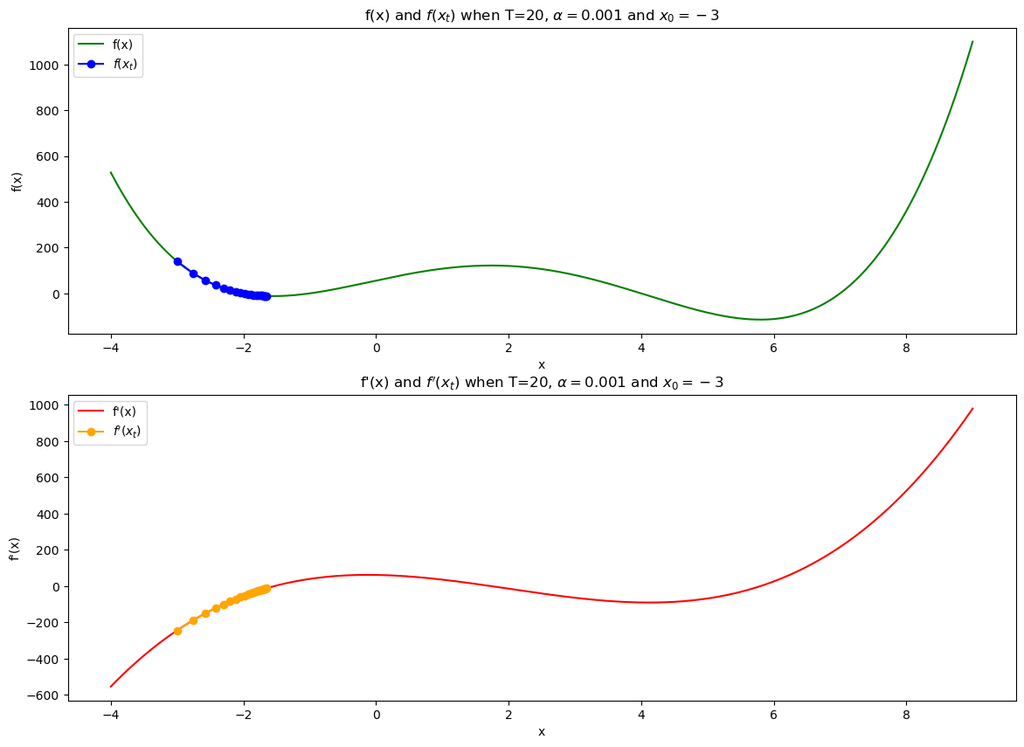

```python
drawFunctionsBasedOnDataFrame(parameters, T[0])
```

We can see that whenever $\alpha$ is smaller (e.g. 0.002 as opposed to 0.02), the changes are generally less radical  
This has various consequenses:

- When $x_0 = 4$:  
  With both $\alpha$־s we arrive at the global minimum point.
- When $x_0 = 8$:  
  With the larger $\alpha(=0.02)$ we arrive at a minimum point but not the global one,  
  whereas with the smaller $\alpha(=0.002)$ we arrive at the global minimum point.
- When $x_0 = -3$:  
  With the larger $\alpha(=0.02)$ we arrive at the global minimum point,  
  whereas with the smaller $\alpha(=0.001)$ we arrive at a minimum point but not the global one.

### When $T = 3$

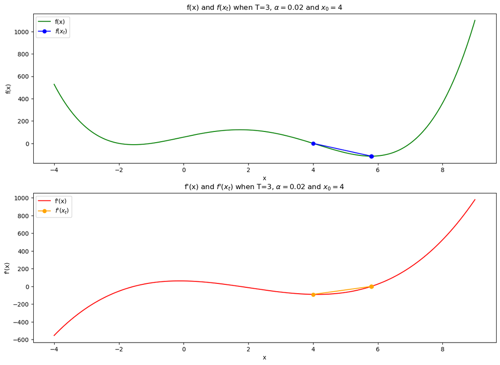

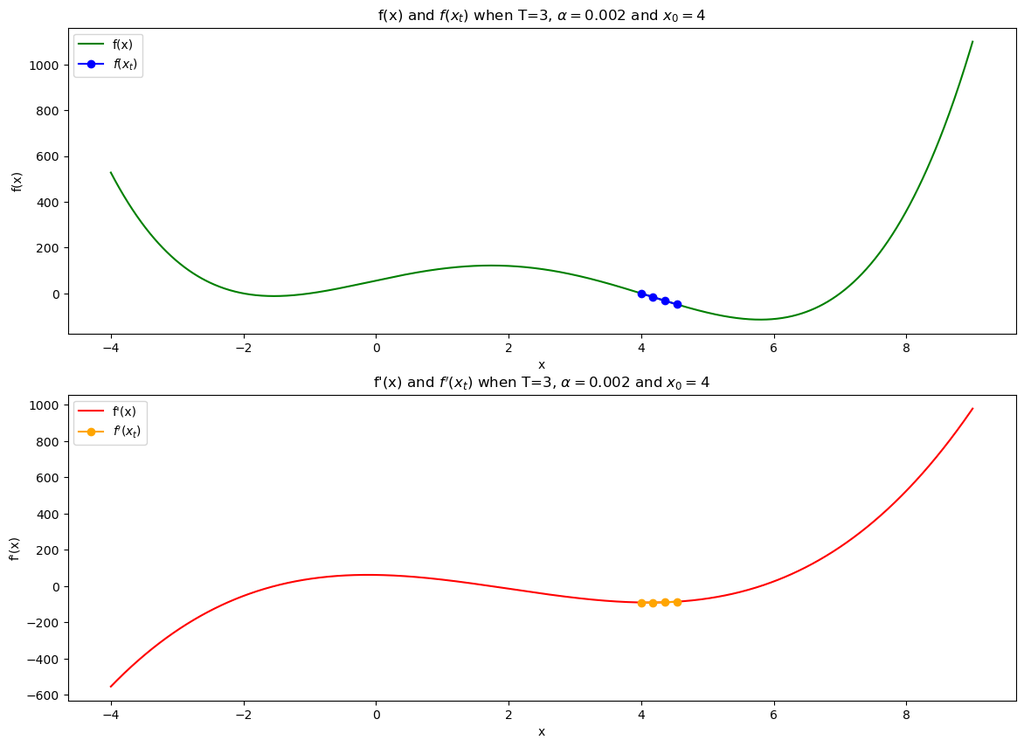

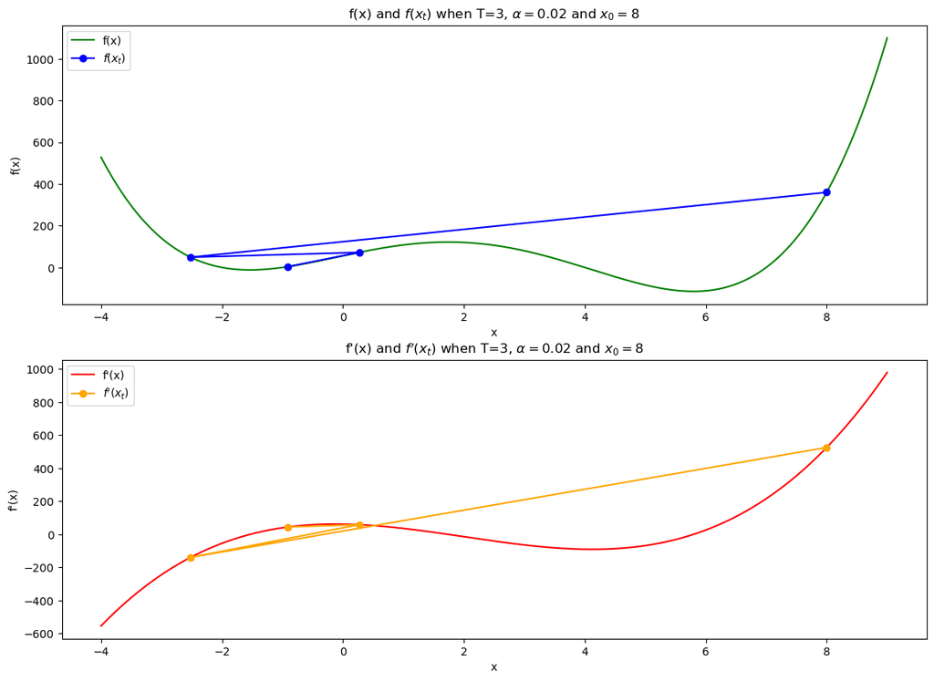

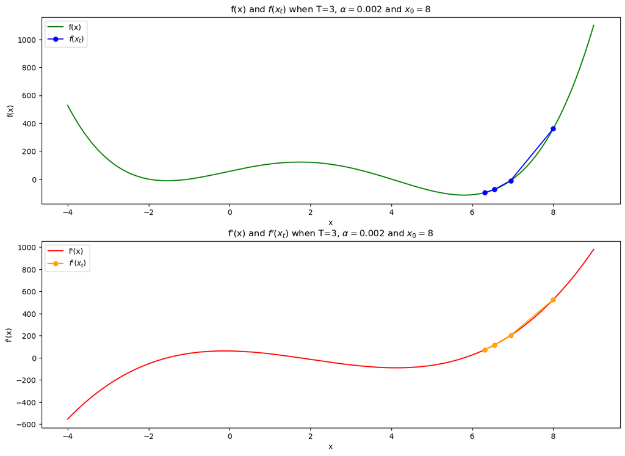

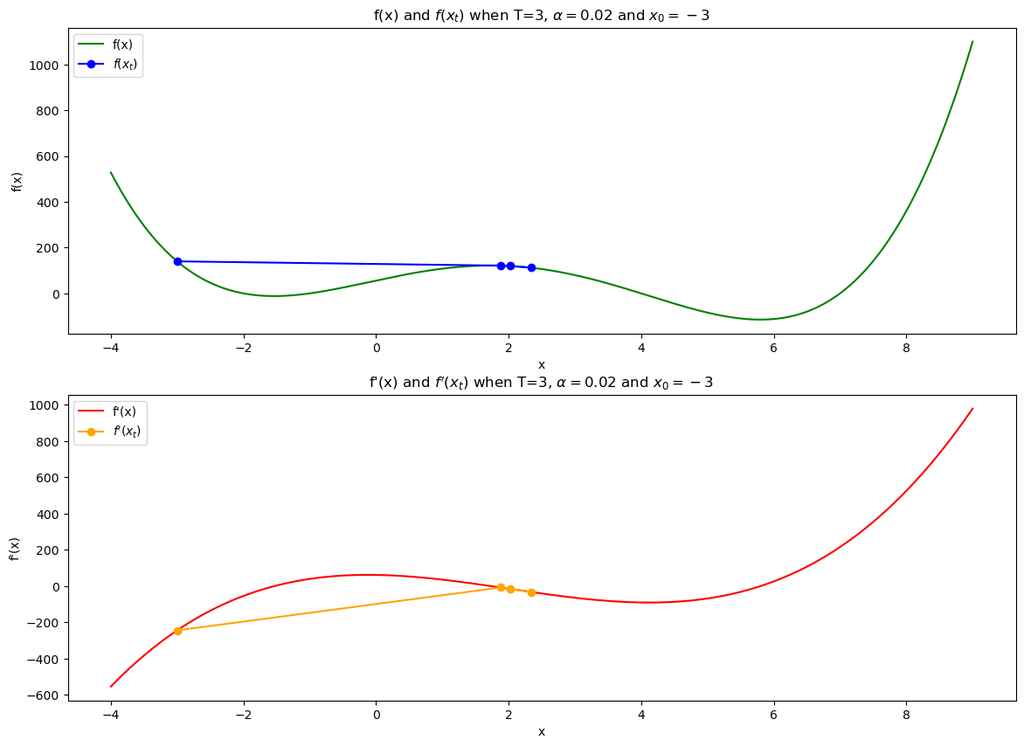

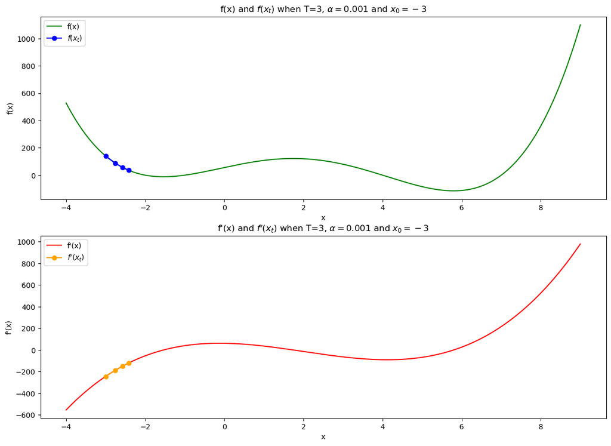

```python
drawFunctionsBasedOnDataFrame(parameters, T[1])
```

We can see that whenever $\alpha$ is smaller (e.g. 0.002 as opposed to 0.02), the changes are generally less radical  
This has various consequenses:

- When $x_0 = 4$:  
  With the larger $\alpha(=0.02)$ we arrive rather close to the global minimum point,  
  however, with the smaller $\alpha(=0.002)$, while we do make progress in that direction, we don't arrive nearly as close to the minimum point.
- When $x_0 = 8$:  
  The larger $\alpha(=0.02)$ brings us close to a minimum point but not the global one.  
  The smaller $\alpha(=0.002)$ on the other hand, brings us close to the global minimum point.
- When $x_0 = -3$:  
  With the larger $\alpha(=0.02)$ we arrive rather close to a maximum point,  
  whereas with the smaller $\alpha(=0.001)$ we make progress towards a minimum point that is not the global one, but we end up quite far from it.

### When $T = 200$

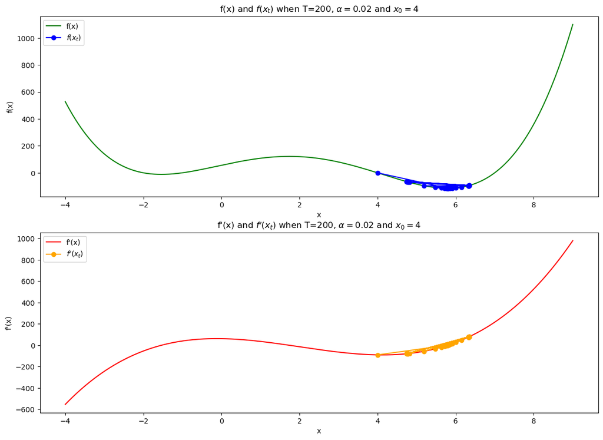

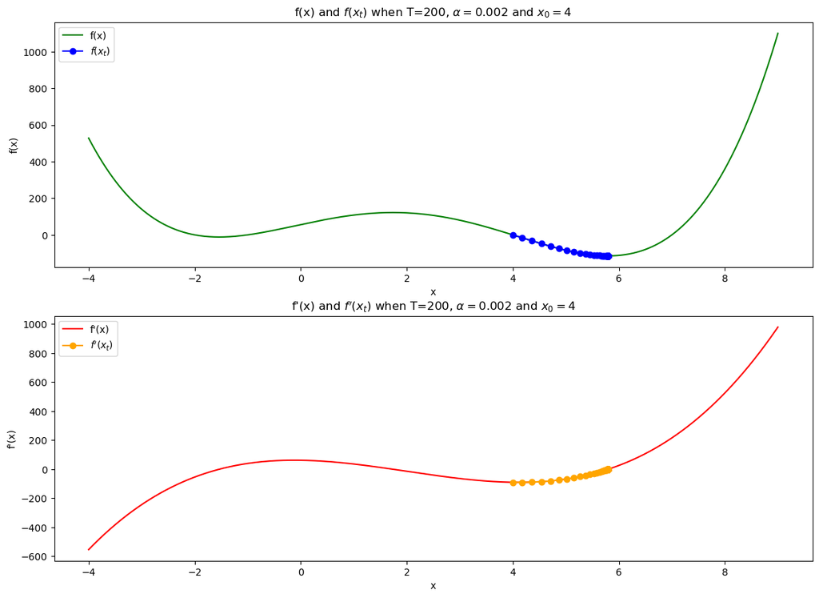

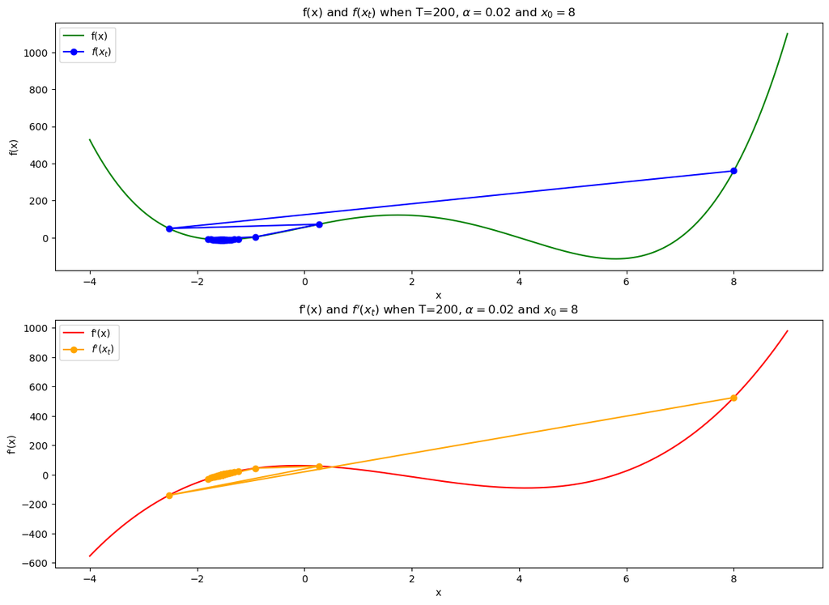

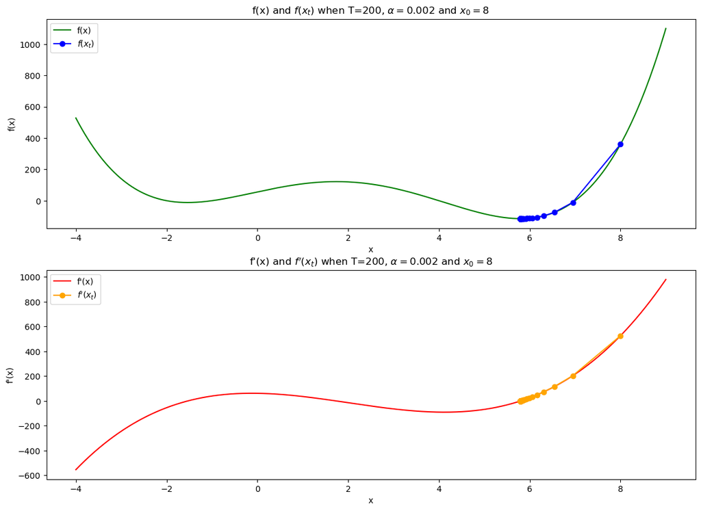

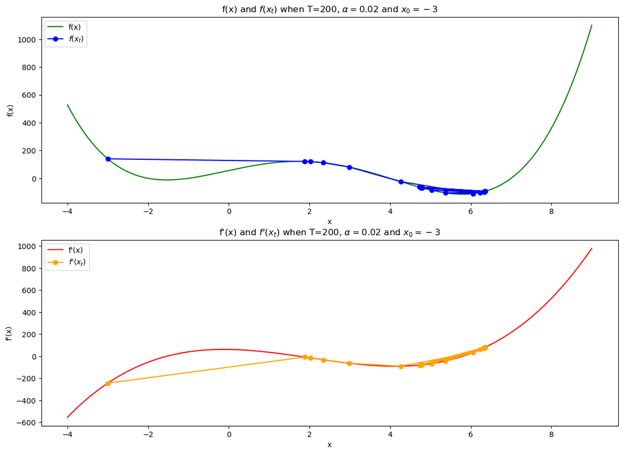

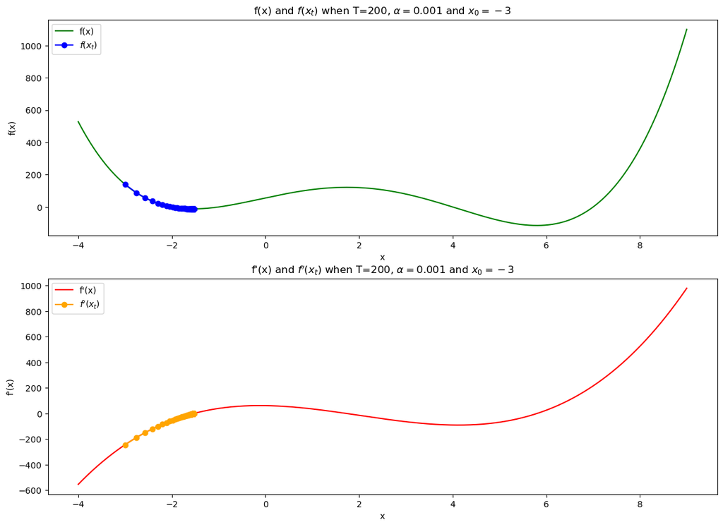

```python
drawFunctionsBasedOnDataFrame(parameters, T[2])
```

We can see that whenever $\alpha$ is smaller (e.g. 0.002 as opposed to 0.02), the changes are generally less radical  
This has various consequenses (these are similar to those of $T=20$ but with better accuracy):

- When $x_0 = 4$:  
  With both $\alpha$־s we arrive at the global minimum point.
- When $x_0 = 8$:  
  With the larger $\alpha(=0.02)$ we arrive at a minimum point but not the global one,  
  whereas with the smaller $\alpha(=0.002)$ we arrive at the global minimum point.
- When $x_0 = -3$:  
  With the larger $\alpha(=0.02)$ we arrive at the global minimum point,  
  whereas with the smaller $\alpha(=0.001)$ we arrive at a minimum point but not the global one.

From the differences in the results for each $T$ we can infer that the more iterations we run the Gradient Descent Algorithm (which translates to more updates), the closer we will end up next to an extrimum point (with our algorithm - a minimum one).  
This, however, is also reliant on $\alpha$. With larger $\alpha$־s we make more radical (larger) adjustments, and depending on the number of iteration $T$, we might finish the process far from an extrimum.  
Another thing to mention is the correlation between the starting point $x_0$ combined with the magnitude of $\alpha$ and the value we get at the end of the process.  
With smaller $\alpha$־s, because we make smaller steps, we generally gravitate towards the extrimum closest to $x_0$. This is in contrast to the progress we make with larger $\alpha$־s, as whenever $\alpha$ is larger we make larger steps, and thus we may gravitate towards extrimum points that are further away from $x_0$.